# Определение стоимости автомобилей

Сервис по продаже автомобилей с пробегом «Не бит, не крашен» разрабатывает приложение для привлечения новых клиентов. В нём можно быстро узнать рыночную стоимость своего автомобиля.

**Цель исследования** - построить модель для определения стоимости автомобиля в приложении.

Заказчику важны:

- качество предсказания;
- скорость предсказания;
- время обучения.

В нашем распоряжении исторические данные: технические характеристики, комплектации и цены автомобилей.

Условия:

- Для оценки качества моделей использовать метрику RMSE;
- Значение метрики RMSE должно быть меньше 2500.

**Ход исследования:**

В начале подготовим данные: проверим датасет на наличие полных и неявных дубликатов, подсчитаем пропуски в данных и проверим соответствие значений в столбцах их типам.

Далее проведём исследовательский анализ данных. Построим графики с распределением и числовым размахом для каждой переменной, попробуем выявить аномалии, выбросы и закономерности, а также рассмотрим распределение автомобилей по категориальным признакам. Перед построением моделей необходимо будет провести корреляционный анализ: построить матрицы корреляций для целевого и входных признаков, оценить наличие мультиколлинеарности.

Подготовим выборки для обучения с учётом особенностей каждой выбранной модели. Для линейной модели LinearRegression используем OHE кодирование категориальных переменных, для моделей KNeighborsRegressor и DecisionTreeRegressor применим порядковое кодирование OrdinalEncoder. В случае с моделью LightGBM переведём категориальные признаки в тип category. Числовые переменные масштабируем.

Перейдём к обучению моделей. Первым делом обучим и оценим линейную модель. С помощью pipeline и RandomizedSearchCV для перебора гиперпараметров подберём лучшую модель из моделей KNeighborsRegressor и DecisionTreeRegressor с учётом метрики качества RMSE - среднеквадратичной ошибки. Также используем RandomizedSearchCV для подбора параметров модели LGBMRegressor. В конце подсчитаем время обучения и предсказания для каждой модели и выберем лучшую по 3 критериям: min время обучения, min время предсказания, RMSE < 2500.

Сформулируем итоговый вывод.

## Импорт библиотек и модулей

```python
!pip install lightgbm
```

```python
import pandas as pd

import seaborn as sns
import matplotlib.pyplot as plt
import matplotlib
from matplotlib.ticker import (MultipleLocator, FormatStrFormatter, AutoMinorLocator)
# импорт библиотек pandas, seaborn, matplotlib.pyplot

import re
import numpy as np
from scipy import stats as st
from scipy.stats import shapiro
from scipy.stats import anderson
import phik

from sklearn.model_selection import train_test_split

from sklearn.pipeline import Pipeline
# загружаем класс pipeline

from sklearn.preprocessing import OneHotEncoder, OrdinalEncoder, StandardScaler, MinMaxScaler, RobustScaler
from sklearn.compose import ColumnTransformer
# загружаем классы для подготовки данных

from sklearn.impute import SimpleImputer
# загружаем класс для работы с пропусками

from sklearn.model_selection import RandomizedSearchCV, GridSearchCV
# импортируем класс RandomizedSearchCV, GridSearchCV

from sklearn.linear_model import LinearRegression
from sklearn.neighbors import KNeighborsRegressor
from sklearn.tree import DecisionTreeRegressor
# загружаем нужные модели

from sklearn.metrics import mean_squared_error
# загружаем функцию для работы с метриками

import lightgbm as lgb

%config InlineBackend.figure_format='jpg'
import warnings
warnings.filterwarnings('ignore')
```

```python
RANDOM_STATE = 42
TEST_SIZE_PIPE = 0.25
TEST_SIZE = 0.5
VALID_SIZE = 0.4
```

## Загрузка и обзор данных

```python
try:
    autos_df = pd.read_csv('/datasets/autos.csv')
except:
    autos_df = pd.read_csv('/Users/galina/Desktop/Яндекс.Практикум/Data Science/Спринт 17 Численные методы/Спринт 17 проект/autos.csv')
# чтение файлов с данными
```

```python
def get_df_info(df):
    display(df.head(10))
    display(df.info())
    display(df.describe(include='all'))
    display(df.columns)
# создание функции для вывода характеристик датафрейма
```

```python
print(f'Характеристики датафрейма: autos_df')
get_df_info(autos_df)
# вывод характеристик для датафрейма
```

```
Характеристики датафрейма: autos_df
```

|  | DateCrawled | Price | VehicleType | RegistrationYear | Gearbox | Power | Model | Kilometer | RegistrationMonth | FuelType | Brand | Repaired | DateCreated | NumberOfPictures | PostalCode | LastSeen |
| --- | --- | --- | --- | --- | --- | --- | --- | --- | --- | --- | --- | --- | --- | --- | --- | --- |
| 0 | 2016-03-24 11:52:17 | 480 | NaN | 1993 | manual | 0 | golf | 150000 | 0 | petrol | volkswagen | NaN | 2016-03-24 00:00:00 | 0 | 70435 | 2016-04-07 03:16:57 |
| 1 | 2016-03-24 10:58:45 | 18300 | coupe | 2011 | manual | 190 | NaN | 125000 | 5 | gasoline | audi | yes | 2016-03-24 00:00:00 | 0 | 66954 | 2016-04-07 01:46:50 |
| 2 | 2016-03-14 12:52:21 | 9800 | suv | 2004 | auto | 163 | grand | 125000 | 8 | gasoline | jeep | NaN | 2016-03-14 00:00:00 | 0 | 90480 | 2016-04-05 12:47:46 |
| 3 | 2016-03-17 16:54:04 | 1500 | small | 2001 | manual | 75 | golf | 150000 | 6 | petrol | volkswagen | no | 2016-03-17 00:00:00 | 0 | 91074 | 2016-03-17 17:40:17 |
| 4 | 2016-03-31 17:25:20 | 3600 | small | 2008 | manual | 69 | fabia | 90000 | 7 | gasoline | skoda | no | 2016-03-31 00:00:00 | 0 | 60437 | 2016-04-06 10:17:21 |
| 5 | 2016-04-04 17:36:23 | 650 | sedan | 1995 | manual | 102 | 3er | 150000 | 10 | petrol | bmw | yes | 2016-04-04 00:00:00 | 0 | 33775 | 2016-04-06 19:17:07 |
| 6 | 2016-04-01 20:48:51 | 2200 | convertible | 2004 | manual | 109 | 2_reihe | 150000 | 8 | petrol | peugeot | no | 2016-04-01 00:00:00 | 0 | 67112 | 2016-04-05 18:18:39 |
| 7 | 2016-03-21 18:54:38 | 0 | sedan | 1980 | manual | 50 | other | 40000 | 7 | petrol | volkswagen | no | 2016-03-21 00:00:00 | 0 | 19348 | 2016-03-25 16:47:58 |
| 8 | 2016-04-04 23:42:13 | 14500 | bus | 2014 | manual | 125 | c_max | 30000 | 8 | petrol | ford | NaN | 2016-04-04 00:00:00 | 0 | 94505 | 2016-04-04 23:42:13 |
| 9 | 2016-03-17 10:53:50 | 999 | small | 1998 | manual | 101 | golf | 150000 | 0 | NaN | volkswagen | NaN | 2016-03-17 00:00:00 | 0 | 27472 | 2016-03-31 17:17:06 |

```
<class 'pandas.core.frame.DataFrame'>
RangeIndex: 354369 entries, 0 to 354368
Data columns (total 16 columns):
 #   Column             Non-Null Count   Dtype
---  ------             --------------   -----
 0   DateCrawled        354369 non-null  object
 1   Price              354369 non-null  int64
 2   VehicleType        316879 non-null  object
 3   RegistrationYear   354369 non-null  int64
 4   Gearbox            334536 non-null  object
 5   Power              354369 non-null  int64
 6   Model              334664 non-null  object
 7   Kilometer          354369 non-null  int64
 8   RegistrationMonth  354369 non-null  int64
 9   FuelType           321474 non-null  object
 10  Brand              354369 non-null  object
 11  Repaired           283215 non-null  object
 12  DateCreated        354369 non-null  object
 13  NumberOfPictures   354369 non-null  int64
 14  PostalCode         354369 non-null  int64
 15  LastSeen           354369 non-null  object
dtypes: int64(7), object(9)
memory usage: 43.3+ MB
```

```
None
```

|  | DateCrawled | Price | VehicleType | RegistrationYear | Gearbox | Power | Model | Kilometer | RegistrationMonth | FuelType | Brand | Repaired | DateCreated | NumberOfPictures | PostalCode | LastSeen |
| --- | --- | --- | --- | --- | --- | --- | --- | --- | --- | --- | --- | --- | --- | --- | --- | --- |
| count | 354369 | 354369.000000 | 316879 | 354369.000000 | 334536 | 354369.000000 | 334664 | 354369.000000 | 354369.000000 | 321474 | 354369 | 283215 | 354369 | 354369.0 | 354369.000000 | 354369 |
| unique | 271174 | NaN | 8 | NaN | 2 | NaN | 250 | NaN | NaN | 7 | 40 | 2 | 109 | NaN | NaN | 179150 |
| top | 2016-03-24 14:49:47 | NaN | sedan | NaN | manual | NaN | golf | NaN | NaN | petrol | volkswagen | no | 2016-04-03 00:00:00 | NaN | NaN | 2016-04-06 13:45:54 |
| freq | 7 | NaN | 91457 | NaN | 268251 | NaN | 29232 | NaN | NaN | 216352 | 77013 | 247161 | 13719 | NaN | NaN | 17 |
| mean | NaN | 4416.656776 | NaN | 2004.234448 | NaN | 110.094337 | NaN | 128211.172535 | 5.714645 | NaN | NaN | NaN | NaN | 0.0 | 50508.689087 | NaN |
| std | NaN | 4514.158514 | NaN | 90.227958 | NaN | 189.850405 | NaN | 37905.341530 | 3.726421 | NaN | NaN | NaN | NaN | 0.0 | 25783.096248 | NaN |
| min | NaN | 0.000000 | NaN | 1000.000000 | NaN | 0.000000 | NaN | 5000.000000 | 0.000000 | NaN | NaN | NaN | NaN | 0.0 | 1067.000000 | NaN |
| 25% | NaN | 1050.000000 | NaN | 1999.000000 | NaN | 69.000000 | NaN | 125000.000000 | 3.000000 | NaN | NaN | NaN | NaN | 0.0 | 30165.000000 | NaN |
| 50% | NaN | 2700.000000 | NaN | 2003.000000 | NaN | 105.000000 | NaN | 150000.000000 | 6.000000 | NaN | NaN | NaN | NaN | 0.0 | 49413.000000 | NaN |
| 75% | NaN | 6400.000000 | NaN | 2008.000000 | NaN | 143.000000 | NaN | 150000.000000 | 9.000000 | NaN | NaN | NaN | NaN | 0.0 | 71083.000000 | NaN |
| max | NaN | 20000.000000 | NaN | 9999.000000 | NaN | 20000.000000 | NaN | 150000.000000 | 12.000000 | NaN | NaN | NaN | NaN | 0.0 | 99998.000000 | NaN |

```
Index(['DateCrawled', 'Price', 'VehicleType', 'RegistrationYear', 'Gearbox',
       'Power', 'Model', 'Kilometer', 'RegistrationMonth', 'FuelType', 'Brand',
       'Repaired', 'DateCreated', 'NumberOfPictures', 'PostalCode',
       'LastSeen'],
      dtype='object')
```

В первую очередь нужно будет перевести **некорректные названия** в нижний 'змеиный' регистр. К возможным **аномальным значениям** можно отнести минимальную цену `Price` - 0 евро, максимальную мощность автомобиля `Power` - 20 000 л.с. и максимальный пробег `Kilometer` - 150 000 км. Также в некоторых столбцах наблюдаются **пропуски**.

### Вывод

В датафрейме *autos_df* содержатся данные о технических характеристиках, комплектации и ценах автомобилей, а также информация о размещённых объявлениях:

1. `Price` - цена в евро, целевой признак;
1. Признаки с описанием технических характеристик и комплектации:
- `VehicleType` — тип автомобильного кузова;
- `RegistrationYear` - год регистрации автомобиля;
- `Gearbox` - тип коробки передач;
- `Power` - мощность (л. с.);
- `Model` - модель автомобиля;
- `Kilometer` - пробег (км);
- `RegistrationMonth` - месяц регистрации автомобиля;
- `FuelType` - тип топлива;
- `Brand` - марка автомобиля;
- `Repaired` - была машина в ремонте или нет;
1. Признаки с информацией о размещённых объявлениях:
- `DateCrawled` - дата скачивания анкеты из базы;
- `DateCreated` - дата создания анкеты;
- `NumberOfPictures` - количество фотографий автомобиля;
- `PostalCode` - почтовый индекс владельца анкеты (пользователя);
- `LastSeen` - дата последней активности пользователя.

Перед построением модели исправим названия столбцов, проверим наши датафреймы на наличие пропусков, неявных и полных дубликатов, а также на корректность типов данных в колонках. Далее изучим распределение каждого параметра и избавимся от выбросов, если это будет необходимо.

## Предобработка данных

```python
print(f'''Таблица autos_df

Названия столбцов:

{autos_df.columns.values}
''')
print(f'Количество явных дубликатов: {autos_df.duplicated(subset=list(autos_df.columns)).sum()}')
display(autos_df[autos_df.duplicated(subset=list(autos_df.columns))])
# вывод строк-дубликатов
print('')
for category in list(autos_df.select_dtypes(include=[object]).columns):
    print(f'Число уникальных совпадений в столбце {category}:')
    display(autos_df[category].value_counts())
    # подсчёт уникальных значений в колонках
    print('')
print(f'Количество пропусков в датафрейме autos_df: \n')
print(autos_df.isna().sum())
# подсчёт пропусков
print('')
print(f'Типы данных по столбцам в autos_df: \n')
# отображение типов данных
print(autos_df.dtypes)
# вывод информации по наличию пропусков, дубликатов, названиям столбцов, типам данных
```

```
Таблица autos_df

Названия столбцов:

['DateCrawled' 'Price' 'VehicleType' 'RegistrationYear' 'Gearbox' 'Power'
 'Model' 'Kilometer' 'RegistrationMonth' 'FuelType' 'Brand' 'Repaired'
 'DateCreated' 'NumberOfPictures' 'PostalCode' 'LastSeen']

Количество явных дубликатов: 4
```

|  | DateCrawled | Price | VehicleType | RegistrationYear | Gearbox | Power | Model | Kilometer | RegistrationMonth | FuelType | Brand | Repaired | DateCreated | NumberOfPictures | PostalCode | LastSeen |
| --- | --- | --- | --- | --- | --- | --- | --- | --- | --- | --- | --- | --- | --- | --- | --- | --- |
| 171088 | 2016-03-08 18:42:48 | 1799 | coupe | 1999 | auto | 193 | clk | 20000 | 7 | petrol | mercedes_benz | no | 2016-03-08 00:00:00 | 0 | 89518 | 2016-03-09 09:46:57 |
| 231258 | 2016-03-28 00:56:10 | 1000 | small | 2002 | manual | 83 | other | 150000 | 1 | petrol | suzuki | no | 2016-03-28 00:00:00 | 0 | 66589 | 2016-03-28 08:46:21 |
| 258109 | 2016-04-03 09:01:15 | 4699 | coupe | 2003 | auto | 218 | clk | 125000 | 6 | petrol | mercedes_benz | yes | 2016-04-03 00:00:00 | 0 | 75196 | 2016-04-07 09:44:54 |
| 325651 | 2016-03-18 18:46:15 | 1999 | wagon | 2001 | manual | 131 | passat | 150000 | 7 | gasoline | volkswagen | no | 2016-03-18 00:00:00 | 0 | 36391 | 2016-03-18 18:46:15 |

```
Число уникальных совпадений в столбце DateCrawled:
```

```
2016-03-24 14:49:47    7
2016-03-26 22:57:31    6
2016-03-19 21:49:56    6
2016-04-02 14:50:21    5
2016-03-23 13:50:19    5
                      ..
2016-03-20 16:48:06    1
2016-03-22 21:51:04    1
2016-03-11 16:25:36    1
2016-03-31 12:47:30    1
2016-03-19 18:57:12    1
Name: DateCrawled, Length: 271174, dtype: int64
```

```
Число уникальных совпадений в столбце VehicleType:
```

```
sedan          91457
small          79831
wagon          65166
bus            28775
convertible    20203
coupe          16163
suv            11996
other           3288
Name: VehicleType, dtype: int64
```

```
Число уникальных совпадений в столбце Gearbox:
```

```
manual    268251
auto       66285
Name: Gearbox, dtype: int64
```

```
Число уникальных совпадений в столбце Model:
```

```
golf                  29232
other                 24421
3er                   19761
polo                  13066
corsa                 12570
                      ...
i3                        8
serie_3                   4
rangerover                4
range_rover_evoque        2
serie_1                   2
Name: Model, Length: 250, dtype: int64
```

```
Число уникальных совпадений в столбце FuelType:
```

```
petrol      216352
gasoline     98720
lpg           5310
cng            565
hybrid         233
other          204
electric        90
Name: FuelType, dtype: int64
```

```
Число уникальных совпадений в столбце Brand:
```

```
volkswagen        77013
opel              39931
bmw               36914
mercedes_benz     32046
audi              29456
ford              25179
renault           17927
peugeot           10998
fiat               9643
seat               6907
mazda              5615
skoda              5500
smart              5246
citroen            5148
nissan             4941
toyota             4606
hyundai            3587
sonstige_autos     3374
volvo              3210
mini               3202
mitsubishi         3022
honda              2817
kia                2465
suzuki             2323
alfa_romeo         2314
chevrolet          1754
chrysler           1439
dacia               900
daihatsu            806
subaru              762
porsche             758
jeep                677
trabant             589
land_rover          545
daewoo              542
saab                526
jaguar              505
rover               486
lancia              471
lada                225
Name: Brand, dtype: int64
```

```
Число уникальных совпадений в столбце Repaired:
```

```
no     247161
yes     36054
Name: Repaired, dtype: int64
```

```
Число уникальных совпадений в столбце DateCreated:
```

```
2016-04-03 00:00:00    13719
2016-04-04 00:00:00    13317
2016-03-20 00:00:00    12918
2016-03-12 00:00:00    12840
2016-03-21 00:00:00    12691
                       ...
2015-08-07 00:00:00        1
2015-12-27 00:00:00        1
2015-11-12 00:00:00        1
2015-12-06 00:00:00        1
2015-06-18 00:00:00        1
Name: DateCreated, Length: 109, dtype: int64
```

```
Число уникальных совпадений в столбце LastSeen:
```

```
2016-04-06 13:45:54    17
2016-04-07 09:45:10    16
2016-04-06 01:15:23    16
2016-04-06 10:15:26    16
2016-04-07 05:44:30    16
                       ..
2016-03-07 17:46:17     1
2016-03-10 07:49:15     1
2016-04-03 04:18:11     1
2016-03-16 20:19:54     1
2016-03-21 10:42:49     1
Name: LastSeen, Length: 179150, dtype: int64
```

```
Количество пропусков в датафрейме autos_df:

DateCrawled              0
Price                    0
VehicleType          37490
RegistrationYear         0
Gearbox              19833
Power                    0
Model                19705
Kilometer                0
RegistrationMonth        0
FuelType             32895
Brand                    0
Repaired             71154
DateCreated              0
NumberOfPictures         0
PostalCode               0
LastSeen                 0
dtype: int64

Типы данных по столбцам в autos_df:

DateCrawled          object
Price                 int64
VehicleType          object
RegistrationYear      int64
Gearbox              object
Power                 int64
Model                object
Kilometer             int64
RegistrationMonth     int64
FuelType             object
Brand                object
Repaired             object
DateCreated          object
NumberOfPictures      int64
PostalCode            int64
LastSeen             object
dtype: object
```

Названия столбцов переведём в нижний регистр и вставим символ "_" между словами.

```python
autos_df.columns = [re.sub(r'([A-Z])', r' \1', x).lower().replace(' ', '_')[1:] for x in autos_df.columns.values]
# вставка и замена символов с использованием регулярного выражения и метода replace
```

```python
autos_df.columns
# проверка названий столбцов
```

```
Index(['date_crawled', 'price', 'vehicle_type', 'registration_year', 'gearbox',
       'power', 'model', 'kilometer', 'registration_month', 'fuel_type',
       'brand', 'repaired', 'date_created', 'number_of_pictures',
       'postal_code', 'last_seen'],
      dtype='object')
```

Удалим 4 явных дубликата.

```python
autos_df = autos_df.drop_duplicates()
# удаление дубликатов
```

```python
autos_df[autos_df.duplicated()]
# проверка наличия явных дубликатов
```

|  | date_crawled | price | vehicle_type | registration_year | gearbox | power | model | kilometer | registration_month | fuel_type | brand | repaired | date_created | number_of_pictures | postal_code | last_seen |
| --- | --- | --- | --- | --- | --- | --- | --- | --- | --- | --- | --- | --- | --- | --- | --- | --- |

```python
np.sort(autos_df[~autos_df['fuel_type'].isna()]['fuel_type'].unique())
# уникальные типы топлива
```

```
array(['cng', 'electric', 'gasoline', 'hybrid', 'lpg', 'other', 'petrol'],
      dtype=object)
```

Наименования gasoline и petrol - слова, которые относятся к одному виду топлива (бензин) для двигателя внутреннего сгорания. Petrol используется в Великобритании, Индии и некоторых других местах, в то время как gasoline или gas используется в США. Заменим gasoline на petrol, чтобы объединить категории.

```python
autos_df['fuel_type'] = autos_df['fuel_type'].replace('gasoline', 'petrol')
# замена значений методом replace
```

```python
autos_df['fuel_type'].value_counts()
# подсчёт уникальных значений fuel_type
```

```
petrol      315068
lpg           5310
cng            565
hybrid         233
other          204
electric        90
Name: fuel_type, dtype: int64
```

```python
np.sort(autos_df[~autos_df['model'].isna()]['model'].unique())
# уникальные модели
```

```
array(['100', '145', '147', '156', '159', '1_reihe', '1er', '200',
       '2_reihe', '300c', '3_reihe', '3er', '4_reihe', '500', '5_reihe',
       '5er', '601', '6_reihe', '6er', '7er', '80', '850', '90', '900',
       '9000', '911', 'a1', 'a2', 'a3', 'a4', 'a5', 'a6', 'a8',
       'a_klasse', 'accord', 'agila', 'alhambra', 'almera', 'altea',
       'amarok', 'antara', 'arosa', 'astra', 'auris', 'avensis', 'aveo',
       'aygo', 'b_klasse', 'b_max', 'beetle', 'berlingo', 'bora',
       'boxster', 'bravo', 'c1', 'c2', 'c3', 'c4', 'c5', 'c_klasse',
       'c_max', 'c_reihe', 'caddy', 'calibra', 'captiva', 'carisma',
       'carnival', 'cayenne', 'cc', 'ceed', 'charade', 'cherokee',
       'citigo', 'civic', 'cl', 'clio', 'clk', 'clubman', 'colt', 'combo',
       'cooper', 'cordoba', 'corolla', 'corsa', 'cr_reihe', 'croma',
       'crossfire', 'cuore', 'cx_reihe', 'defender', 'delta', 'discovery',
       'doblo', 'ducato', 'duster', 'e_klasse', 'elefantino', 'eos',
       'escort', 'espace', 'exeo', 'fabia', 'fiesta', 'focus', 'forester',
       'forfour', 'fortwo', 'fox', 'freelander', 'fusion', 'g_klasse',
       'galant', 'galaxy', 'getz', 'gl', 'glk', 'golf', 'grand', 'i3',
       'i_reihe', 'ibiza', 'impreza', 'insignia', 'jazz', 'jetta',
       'jimny', 'juke', 'justy', 'ka', 'kadett', 'kaefer', 'kalina',
       'kalos', 'kangoo', 'kappa', 'kuga', 'laguna', 'lancer', 'lanos',
       'legacy', 'leon', 'lodgy', 'logan', 'lupo', 'lybra', 'm_klasse',
       'm_reihe', 'materia', 'matiz', 'megane', 'meriva', 'micra', 'mii',
       'modus', 'mondeo', 'move', 'musa', 'mustang', 'mx_reihe', 'navara',
       'niva', 'note', 'nubira', 'octavia', 'omega', 'one', 'other',
       'outlander', 'pajero', 'panda', 'passat', 'phaeton', 'picanto',
       'polo', 'primera', 'ptcruiser', 'punto', 'q3', 'q5', 'q7',
       'qashqai', 'r19', 'range_rover', 'range_rover_evoque',
       'range_rover_sport', 'rangerover', 'rav', 'rio', 'roadster',
       'roomster', 'rx_reihe', 's60', 's_klasse', 's_max', 's_type',
       'samara', 'sandero', 'santa', 'scenic', 'scirocco', 'seicento',
       'serie_1', 'serie_2', 'serie_3', 'sharan', 'signum', 'sirion',
       'sl', 'slk', 'sorento', 'spark', 'spider', 'sportage', 'sprinter',
       'stilo', 'superb', 'swift', 'terios', 'tigra', 'tiguan', 'toledo',
       'touareg', 'touran', 'transit', 'transporter', 'tt', 'tucson',
       'twingo', 'up', 'v40', 'v50', 'v60', 'v70', 'v_klasse', 'vectra',
       'verso', 'viano', 'vito', 'vivaro', 'voyager', 'wrangler',
       'x_reihe', 'x_trail', 'x_type', 'xc_reihe', 'yaris', 'yeti',
       'ypsilon', 'z_reihe', 'zafira'], dtype=object)
```

```python
np.sort(autos_df['brand'].unique())
# уникальные названия брендов
```

```
array(['alfa_romeo', 'audi', 'bmw', 'chevrolet', 'chrysler', 'citroen',
       'dacia', 'daewoo', 'daihatsu', 'fiat', 'ford', 'honda', 'hyundai',
       'jaguar', 'jeep', 'kia', 'lada', 'lancia', 'land_rover', 'mazda',
       'mercedes_benz', 'mini', 'mitsubishi', 'nissan', 'opel', 'peugeot',
       'porsche', 'renault', 'rover', 'saab', 'seat', 'skoda', 'smart',
       'sonstige_autos', 'subaru', 'suzuki', 'toyota', 'trabant',
       'volkswagen', 'volvo'], dtype=object)
```

```python
round(autos_df.isna().sum() / len(autos_df) * 100, 1)
# вывод доли пропущенных значений для каждого столбца
```

```
date_crawled           0.0
price                  0.0
vehicle_type          10.6
registration_year      0.0
gearbox                5.6
power                  0.0
model                  5.6
kilometer              0.0
registration_month     0.0
fuel_type              9.3
brand                  0.0
repaired              20.1
date_created           0.0
number_of_pictures     0.0
postal_code            0.0
last_seen              0.0
dtype: float64
```

Больше всего пропущенных значений в столбце `repaired` - 20%. В колонке `vehicle_type` - 10.6%. Если мы удалим строки с пропусками, большая часть данных будет потеряна. Попробуем заполнить их.

```python
autos_df[autos_df['vehicle_type'].isna()].head()
# срез данных
```

|  | date_crawled | price | vehicle_type | registration_year | gearbox | power | model | kilometer | registration_month | fuel_type | brand | repaired | date_created | number_of_pictures | postal_code | last_seen |
| --- | --- | --- | --- | --- | --- | --- | --- | --- | --- | --- | --- | --- | --- | --- | --- | --- |
| 0 | 2016-03-24 11:52:17 | 480 | NaN | 1993 | manual | 0 | golf | 150000 | 0 | petrol | volkswagen | NaN | 2016-03-24 00:00:00 | 0 | 70435 | 2016-04-07 03:16:57 |
| 16 | 2016-04-01 12:46:46 | 300 | NaN | 2016 | NaN | 60 | polo | 150000 | 0 | petrol | volkswagen | NaN | 2016-04-01 00:00:00 | 0 | 38871 | 2016-04-01 12:46:46 |
| 22 | 2016-03-23 14:52:51 | 2900 | NaN | 2018 | manual | 90 | meriva | 150000 | 5 | petrol | opel | no | 2016-03-23 00:00:00 | 0 | 49716 | 2016-03-31 01:16:33 |
| 26 | 2016-03-10 19:38:18 | 5555 | NaN | 2017 | manual | 125 | c4 | 125000 | 4 | NaN | citroen | no | 2016-03-10 00:00:00 | 0 | 31139 | 2016-03-16 09:16:46 |
| 31 | 2016-03-29 16:57:02 | 899 | NaN | 2016 | manual | 60 | clio | 150000 | 6 | petrol | renault | NaN | 2016-03-29 00:00:00 | 0 | 37075 | 2016-03-29 17:43:07 |

Можно заменить отсутствующие значения в столбце `vehicle_type` **модой** (наиболее часто встречающимся значением), учитывая модель автомобиля.

```python
for model in list(autos_df['model'].unique()):
    try:
        autos_df.loc[((autos_df['model'] == model) & (autos_df['vehicle_type'].isna())), 'vehicle_type'] = autos_df[(autos_df['model'] == model)]['vehicle_type'].mode().loc[0]
    except:
        continue
# замена пропущенных значений в столбце vehicle_type с учётом модели авто
```

```python
autos_df['vehicle_type'].isna().sum()
# подсчёт оставшихся пропусков
```

```
6828
```

Оставшиеся пропуски заполним значением 'other'.

```python
autos_df['vehicle_type'].fillna('other', inplace=True)
# заполнение пропусков
```

Таким же образом заполним пропуски в колонках `gearbox` и `fuel_type`.

```python
autos_df[autos_df['gearbox'].isna()].head()
# срез данных
```

|  | date_crawled | price | vehicle_type | registration_year | gearbox | power | model | kilometer | registration_month | fuel_type | brand | repaired | date_created | number_of_pictures | postal_code | last_seen |
| --- | --- | --- | --- | --- | --- | --- | --- | --- | --- | --- | --- | --- | --- | --- | --- | --- |
| 15 | 2016-03-11 21:39:15 | 450 | small | 1910 | NaN | 0 | ka | 5000 | 0 | petrol | ford | NaN | 2016-03-11 00:00:00 | 0 | 24148 | 2016-03-19 08:46:47 |
| 16 | 2016-04-01 12:46:46 | 300 | small | 2016 | NaN | 60 | polo | 150000 | 0 | petrol | volkswagen | NaN | 2016-04-01 00:00:00 | 0 | 38871 | 2016-04-01 12:46:46 |
| 32 | 2016-03-15 20:59:01 | 245 | sedan | 1994 | NaN | 0 | golf | 150000 | 2 | petrol | volkswagen | no | 2016-03-15 00:00:00 | 0 | 44145 | 2016-03-17 18:17:43 |
| 37 | 2016-03-28 17:50:15 | 1500 | bus | 2016 | NaN | 0 | kangoo | 150000 | 1 | petrol | renault | no | 2016-03-28 00:00:00 | 0 | 46483 | 2016-03-30 09:18:02 |
| 40 | 2016-03-26 22:06:17 | 0 | small | 1990 | NaN | 0 | corsa | 150000 | 1 | petrol | opel | NaN | 2016-03-26 00:00:00 | 0 | 56412 | 2016-03-27 17:43:34 |

```python
for model in list(autos_df['model'].unique()):
    try:
        autos_df.loc[((autos_df['model'] == model) & (autos_df['gearbox'].isna())), 'gearbox'] = autos_df[(autos_df['model'] == model)]['gearbox'].mode().loc[0]
    except:
        continue
# замена пропущенных значений в столбце gearbox с учётом модели авто
```

```python
autos_df['gearbox'].isna().sum()
# подсчёт оставшихся пропусков
```

```
4131
```

```python
autos_df['gearbox'].fillna('unknown', inplace=True)
# заполнение пропусков
```

```python
autos_df[autos_df['fuel_type'].isna()].head()
# срез данных
```

|  | date_crawled | price | vehicle_type | registration_year | gearbox | power | model | kilometer | registration_month | fuel_type | brand | repaired | date_created | number_of_pictures | postal_code | last_seen |
| --- | --- | --- | --- | --- | --- | --- | --- | --- | --- | --- | --- | --- | --- | --- | --- | --- |
| 9 | 2016-03-17 10:53:50 | 999 | small | 1998 | manual | 101 | golf | 150000 | 0 | NaN | volkswagen | NaN | 2016-03-17 00:00:00 | 0 | 27472 | 2016-03-31 17:17:06 |
| 13 | 2016-03-21 21:37:40 | 2500 | wagon | 2004 | manual | 131 | passat | 150000 | 2 | NaN | volkswagen | no | 2016-03-21 00:00:00 | 0 | 90762 | 2016-03-23 02:50:54 |
| 26 | 2016-03-10 19:38:18 | 5555 | sedan | 2017 | manual | 125 | c4 | 125000 | 4 | NaN | citroen | no | 2016-03-10 00:00:00 | 0 | 31139 | 2016-03-16 09:16:46 |
| 36 | 2016-03-11 11:50:37 | 1600 | other | 1991 | manual | 75 | kadett | 70000 | 0 | NaN | opel | NaN | 2016-03-11 00:00:00 | 0 | 2943 | 2016-04-07 03:46:09 |
| 41 | 2016-03-30 20:38:20 | 7500 | sedan | 2002 | auto | 306 | e_klasse | 150000 | 4 | NaN | mercedes_benz | NaN | 2016-03-30 00:00:00 | 0 | 33649 | 2016-04-03 11:44:49 |

```python
for model in list(autos_df['model'].unique()):
    try:
        autos_df.loc[((autos_df['model'] == model) & (autos_df['fuel_type'].isna())), 'fuel_type'] = autos_df[(autos_df['model'] == model)]['fuel_type'].mode().loc[0]
    except:
        continue
# замена пропущенных значений в столбце gearbox с учётом модели авто
```

```python
autos_df['fuel_type'].isna().sum()
# подсчёт оставшихся пропусков
```

```
7163
```

```python
autos_df['fuel_type'].fillna('other', inplace=True)
# заполнение пропусков
```

Пропуски в столбцах `model` и `repaired` заполним значениями 'other' и 'unknown' соответственно.

```python
autos_df[autos_df['model'].isna()].head()
# срез данных
```

|  | date_crawled | price | vehicle_type | registration_year | gearbox | power | model | kilometer | registration_month | fuel_type | brand | repaired | date_created | number_of_pictures | postal_code | last_seen |
| --- | --- | --- | --- | --- | --- | --- | --- | --- | --- | --- | --- | --- | --- | --- | --- | --- |
| 1 | 2016-03-24 10:58:45 | 18300 | coupe | 2011 | manual | 190 | NaN | 125000 | 5 | petrol | audi | yes | 2016-03-24 00:00:00 | 0 | 66954 | 2016-04-07 01:46:50 |
| 59 | 2016-03-29 15:48:15 | 1 | suv | 1994 | manual | 286 | NaN | 150000 | 11 | other | sonstige_autos | NaN | 2016-03-29 00:00:00 | 0 | 53721 | 2016-04-06 01:44:38 |
| 81 | 2016-04-03 12:56:45 | 350 | small | 1997 | manual | 54 | NaN | 150000 | 3 | other | fiat | yes | 2016-04-03 00:00:00 | 0 | 45665 | 2016-04-05 11:47:13 |
| 115 | 2016-03-20 18:53:27 | 0 | small | 1999 | unknown | 0 | NaN | 5000 | 0 | petrol | volkswagen | NaN | 2016-03-20 00:00:00 | 0 | 37520 | 2016-04-07 02:45:22 |
| 135 | 2016-03-27 20:51:23 | 1450 | sedan | 1992 | manual | 136 | NaN | 150000 | 0 | other | audi | no | 2016-03-27 00:00:00 | 0 | 38709 | 2016-04-05 20:17:31 |

```python
autos_df['model'].fillna('other', inplace=True)
# заполнение пропусков
```

```python
autos_df[autos_df['repaired'].isna()].head()
# срез данных
```

|  | date_crawled | price | vehicle_type | registration_year | gearbox | power | model | kilometer | registration_month | fuel_type | brand | repaired | date_created | number_of_pictures | postal_code | last_seen |
| --- | --- | --- | --- | --- | --- | --- | --- | --- | --- | --- | --- | --- | --- | --- | --- | --- |
| 0 | 2016-03-24 11:52:17 | 480 | sedan | 1993 | manual | 0 | golf | 150000 | 0 | petrol | volkswagen | NaN | 2016-03-24 00:00:00 | 0 | 70435 | 2016-04-07 03:16:57 |
| 2 | 2016-03-14 12:52:21 | 9800 | suv | 2004 | auto | 163 | grand | 125000 | 8 | petrol | jeep | NaN | 2016-03-14 00:00:00 | 0 | 90480 | 2016-04-05 12:47:46 |
| 8 | 2016-04-04 23:42:13 | 14500 | bus | 2014 | manual | 125 | c_max | 30000 | 8 | petrol | ford | NaN | 2016-04-04 00:00:00 | 0 | 94505 | 2016-04-04 23:42:13 |
| 9 | 2016-03-17 10:53:50 | 999 | small | 1998 | manual | 101 | golf | 150000 | 0 | petrol | volkswagen | NaN | 2016-03-17 00:00:00 | 0 | 27472 | 2016-03-31 17:17:06 |
| 12 | 2016-03-15 22:49:09 | 999 | wagon | 1995 | manual | 115 | passat | 150000 | 11 | petrol | volkswagen | NaN | 2016-03-15 00:00:00 | 0 | 37269 | 2016-04-01 13:16:16 |

```python
autos_df['repaired'].fillna('unknown', inplace=True)
# заполнение пропусков
```

```python
autos_df.isna().sum()
# подсчёт пропусков
```

```
date_crawled          0
price                 0
vehicle_type          0
registration_year     0
gearbox               0
power                 0
model                 0
kilometer             0
registration_month    0
fuel_type             0
brand                 0
repaired              0
date_created          0
number_of_pictures    0
postal_code           0
last_seen             0
dtype: int64
```

```python
np.sort(autos_df['date_crawled'].unique())
# уникальные значения в столбце date_crawled
```

```
array(['2016-03-05 14:06:22', '2016-03-05 14:06:23',
       '2016-03-05 14:06:24', ..., '2016-04-07 14:36:55',
       '2016-04-07 14:36:56', '2016-04-07 14:36:58'], dtype=object)
```

```python
np.sort(autos_df['date_created'].unique())
# уникальные значения в столбце date_created
```

```
array(['2014-03-10 00:00:00', '2015-03-20 00:00:00',
       '2015-06-18 00:00:00', '2015-08-07 00:00:00',
       '2015-08-10 00:00:00', '2015-09-04 00:00:00',
       '2015-09-09 00:00:00', '2015-11-02 00:00:00',
       '2015-11-08 00:00:00', '2015-11-10 00:00:00',
       '2015-11-12 00:00:00', '2015-11-17 00:00:00',
       '2015-11-23 00:00:00', '2015-11-24 00:00:00',
       '2015-12-05 00:00:00', '2015-12-06 00:00:00',
       '2015-12-17 00:00:00', '2015-12-27 00:00:00',
       '2015-12-30 00:00:00', '2016-01-02 00:00:00',
       '2016-01-03 00:00:00', '2016-01-06 00:00:00',
       '2016-01-07 00:00:00', '2016-01-08 00:00:00',
       '2016-01-10 00:00:00', '2016-01-13 00:00:00',
       '2016-01-15 00:00:00', '2016-01-16 00:00:00',
       '2016-01-17 00:00:00', '2016-01-18 00:00:00',
       '2016-01-19 00:00:00', '2016-01-20 00:00:00',
       '2016-01-22 00:00:00', '2016-01-23 00:00:00',
       '2016-01-24 00:00:00', '2016-01-25 00:00:00',
       '2016-01-26 00:00:00', '2016-01-27 00:00:00',
       '2016-01-28 00:00:00', '2016-01-29 00:00:00',
       '2016-01-30 00:00:00', '2016-01-31 00:00:00',
       '2016-02-01 00:00:00', '2016-02-02 00:00:00',
       '2016-02-03 00:00:00', '2016-02-04 00:00:00',
       '2016-02-05 00:00:00', '2016-02-06 00:00:00',
       '2016-02-07 00:00:00', '2016-02-08 00:00:00',
       '2016-02-09 00:00:00', '2016-02-10 00:00:00',
       '2016-02-11 00:00:00', '2016-02-12 00:00:00',
       '2016-02-13 00:00:00', '2016-02-14 00:00:00',
       '2016-02-15 00:00:00', '2016-02-16 00:00:00',
       '2016-02-17 00:00:00', '2016-02-18 00:00:00',
       '2016-02-19 00:00:00', '2016-02-20 00:00:00',
       '2016-02-21 00:00:00', '2016-02-22 00:00:00',
       '2016-02-23 00:00:00', '2016-02-24 00:00:00',
       '2016-02-25 00:00:00', '2016-02-26 00:00:00',
       '2016-02-27 00:00:00', '2016-02-28 00:00:00',
       '2016-02-29 00:00:00', '2016-03-01 00:00:00',
       '2016-03-02 00:00:00', '2016-03-03 00:00:00',
       '2016-03-04 00:00:00', '2016-03-05 00:00:00',
       '2016-03-06 00:00:00', '2016-03-07 00:00:00',
       '2016-03-08 00:00:00', '2016-03-09 00:00:00',
       '2016-03-10 00:00:00', '2016-03-11 00:00:00',
       '2016-03-12 00:00:00', '2016-03-13 00:00:00',
       '2016-03-14 00:00:00', '2016-03-15 00:00:00',
       '2016-03-16 00:00:00', '2016-03-17 00:00:00',
       '2016-03-18 00:00:00', '2016-03-19 00:00:00',
       '2016-03-20 00:00:00', '2016-03-21 00:00:00',
       '2016-03-22 00:00:00', '2016-03-23 00:00:00',
       '2016-03-24 00:00:00', '2016-03-25 00:00:00',
       '2016-03-26 00:00:00', '2016-03-27 00:00:00',
       '2016-03-28 00:00:00', '2016-03-29 00:00:00',
       '2016-03-30 00:00:00', '2016-03-31 00:00:00',
       '2016-04-01 00:00:00', '2016-04-02 00:00:00',
       '2016-04-03 00:00:00', '2016-04-04 00:00:00',
       '2016-04-05 00:00:00', '2016-04-06 00:00:00',
       '2016-04-07 00:00:00'], dtype=object)
```

Удалим неинформативные признаки, которые мы не будем использовать для построения модели.

```python
autos_df = autos_df.drop(['date_crawled', 'date_created', 'number_of_pictures', 'postal_code', 'last_seen'], axis=1)
# удаление ненужных столбцов
```

```python
autos_df.dtypes
# типы данных
```

```
price                  int64
vehicle_type          object
registration_year      int64
gearbox               object
power                  int64
model                 object
kilometer              int64
registration_month     int64
fuel_type             object
brand                 object
repaired              object
dtype: object
```

Все типы данных указаны корректно.

Проверим все уникальные даты регистрации автомобилей.

```python
np.sort(autos_df['registration_year'].unique())
# вывод уникальных значений столбца registration_year
```

```
array([1000, 1001, 1039, 1111, 1200, 1234, 1253, 1255, 1300, 1400, 1500,
       1600, 1602, 1688, 1800, 1910, 1915, 1919, 1920, 1923, 1925, 1927,
       1928, 1929, 1930, 1931, 1932, 1933, 1934, 1935, 1936, 1937, 1938,
       1940, 1941, 1942, 1943, 1944, 1945, 1946, 1947, 1948, 1949, 1950,
       1951, 1952, 1953, 1954, 1955, 1956, 1957, 1958, 1959, 1960, 1961,
       1962, 1963, 1964, 1965, 1966, 1967, 1968, 1969, 1970, 1971, 1972,
       1973, 1974, 1975, 1976, 1977, 1978, 1979, 1980, 1981, 1982, 1983,
       1984, 1985, 1986, 1987, 1988, 1989, 1990, 1991, 1992, 1993, 1994,
       1995, 1996, 1997, 1998, 1999, 2000, 2001, 2002, 2003, 2004, 2005,
       2006, 2007, 2008, 2009, 2010, 2011, 2012, 2013, 2014, 2015, 2016,
       2017, 2018, 2019, 2066, 2200, 2222, 2290, 2500, 2800, 2900, 3000,
       3200, 3500, 3700, 3800, 4000, 4100, 4500, 4800, 5000, 5300, 5555,
       5600, 5900, 5911, 6000, 6500, 7000, 7100, 7500, 7800, 8000, 8200,
       8455, 8500, 8888, 9000, 9229, 9450, 9996, 9999])
```

```python
autos_df[autos_df['registration_year'] > 2016].head()
# срез данных
```

|  | price | vehicle_type | registration_year | gearbox | power | model | kilometer | registration_month | fuel_type | brand | repaired |
| --- | --- | --- | --- | --- | --- | --- | --- | --- | --- | --- | --- |
| 22 | 2900 | bus | 2018 | manual | 90 | meriva | 150000 | 5 | petrol | opel | no |
| 26 | 5555 | sedan | 2017 | manual | 125 | c4 | 125000 | 4 | petrol | citroen | no |
| 48 | 7750 | sedan | 2017 | manual | 80 | golf | 100000 | 1 | petrol | volkswagen | unknown |
| 51 | 2000 | small | 2017 | manual | 90 | punto | 150000 | 11 | petrol | fiat | yes |
| 57 | 2399 | sedan | 2018 | manual | 64 | other | 125000 | 3 | petrol | seat | no |

Для учёта авто и мототехники **в 1931 г.** в СССР был разработан и введён в действие единый стандарт регистрации транспортных средств и номерных знаков. Оставим только авто, зарегистрированные после 1931 г.

Также удалим строки с автомобилями, зарегистрированными **после 2016 г.**, так как они похожи на аномалии и содержат неизвестные значения в некоторых столбцах. К тому же самая поздняя дата скачивания анкеты из базы приходится на 2016 г.

```python
autos_df_copy = autos_df.copy()
# копирование датафрейма
```

```python
autos_df = autos_df[(autos_df['registration_year'] <= 2016) & (autos_df['registration_year'] >= 1931)]
# срез данных
```

```python
print(f'Процент удалённых строк: {round((1 - (autos_df.shape[0] / autos_df_copy.shape[0])) * 100, 2)}%')
```

```
Процент удалённых строк: 4.15%
```

```python
autos_df['registration_month'].unique()
# вывод уникальных значений столбца registration_month
```

```
array([ 0,  5,  8,  6,  7, 10, 12, 11,  2,  3,  1,  4,  9])
```

```python
autos_df[autos_df['registration_month'] == 0].head()
# срез данных
```

|  | price | vehicle_type | registration_year | gearbox | power | model | kilometer | registration_month | fuel_type | brand | repaired |
| --- | --- | --- | --- | --- | --- | --- | --- | --- | --- | --- | --- |
| 0 | 480 | sedan | 1993 | manual | 0 | golf | 150000 | 0 | petrol | volkswagen | unknown |
| 9 | 999 | small | 1998 | manual | 101 | golf | 150000 | 0 | petrol | volkswagen | unknown |
| 16 | 300 | small | 2016 | manual | 60 | polo | 150000 | 0 | petrol | volkswagen | unknown |
| 36 | 1600 | other | 1991 | manual | 75 | kadett | 70000 | 0 | petrol | opel | unknown |
| 54 | 4700 | wagon | 2005 | manual | 0 | signum | 150000 | 0 | petrol | opel | no |

**Нули** вместо номера мясяца могут обозначать отсутствие данных. Оставим как есть.

## Исследовательский анализ данных

### Анализ распределения признаков

```python
num_columns = ['price', 'power', 'kilometer']
cat_columns = ['vehicle_type', 'gearbox', 'model', 'fuel_type', 'brand', 'repaired', 'registration_year', 'registration_month']
# создаём списки с названиями признаков числовых и категориальных
```

```python
matplotlib.rcParams['font.family'] = 'serif'
# изменение шрифта
def show_distribution_graphs(df, column):
    fig = plt.figure(figsize=(11, 5))
    ax1 = fig.add_subplot(1, 2, 1)
    ax2 = fig.add_subplot(1, 2, 2)
    # создание сетки из подграфиков
    ax1.grid(which='major', linewidth=1, color='gray', alpha=0.2)
    ax2.grid(which='major', linewidth=1, color='gray',  alpha=0.2)
    # изменение параметров сетки
    ax2.yaxis.set_minor_locator(AutoMinorLocator())
    ax2.tick_params(which='minor', length=2, width=1)
    # изменение параметров делений на осях
    ax1.spines['top'].set_visible(False)
    ax1.spines['right'].set_visible(False)
    ax1.spines['bottom'].set_visible(False)
    ax2.spines['top'].set_visible(False)
    ax2.spines['right'].set_visible(False)
    # удаление линий осей
    ax1.xaxis.set_visible(False)

    fig.suptitle(f'''Гистограмма и диаграмма размаха параметра: \n{column}''',
                 fontsize=14,
                 fontweight='demi',
                 color='#1B1B17')
    # добавление заголовка

    df.boxplot(column,
               ax=ax1,
               widths=0.3,
               showmeans=True,
               meanline=True,
               color='black',
               flierprops=dict(marker='D', markerfacecolor='white', markeredgecolor='#C1DFF9', linewidth=2),
               medianprops=dict(linewidth=1.7, color='#7990A3'),
               boxprops=dict(linewidth=1.5, color='#C1DFF9'),
               meanprops=dict(linewidth=1.5, color='#163B88')
              )
    # создание диаграммы размаха

    df.hist(column, ax=ax2, color='#C1DFF9', bins=12)
    ax2.set_title(None)
    # создание гистограммы

    fig.tight_layout()
    plt.show()
    # вывод графиков

    shapiro_test, anderson_test = shapiro(df[column]), anderson(df[column])
    print(shapiro_test)
    print('')
    print(anderson_test)
    # получение результатов тестов Шапиро-Уилка и Андерсона-Дарлинга на нормальность распределения
    display(round(df[column].describe().loc[['mean', 'std', 'max', 'min', '50%']], 2))
    print(f'Коэффициент асимметрии: {round(df[column].skew(), 2)} \n')
    print(f'Коэффициент эксцесса: {round(df[column].kurt(), 2)} \n')
# создание функции для построения графиков распределения числовых величин: гистограммы и диаграммы размаха
```

```
Датафрейм autos_df:
```

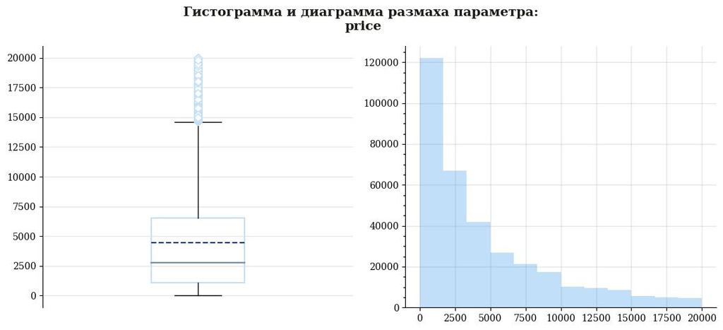

```
ShapiroResult(statistic=0.8315129280090332, pvalue=0.0)

AndersonResult(statistic=18843.55335565342, critical_values=array([0.576, 0.656, 0.787, 0.918, 1.092]), significance_level=array([15. , 10. ,  5. ,  2.5,  1. ]), fit_result=  params: FitParams(loc=4472.346375228545, scale=4545.902723214235)
 success: True
 message: '`anderson` successfully fit the distribution to the data.')
```

```
mean     4472.35
std      4545.90
max     20000.00
min         0.00
50%      2799.00
Name: price, dtype: float64
```

```
Коэффициент асимметрии: 1.41

Коэффициент эксцесса: 1.32
```

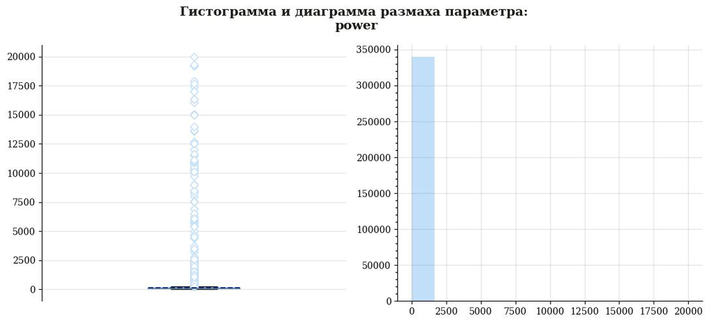

```
ShapiroResult(statistic=0.1568063497543335, pvalue=0.0)

AndersonResult(statistic=53805.3134404922, critical_values=array([0.576, 0.656, 0.787, 0.918, 1.092]), significance_level=array([15. , 10. ,  5. ,  2.5,  1. ]), fit_result=  params: FitParams(loc=111.03313420619521, scale=186.89452277833516)
 success: True
 message: '`anderson` successfully fit the distribution to the data.')
```

```
mean      111.03
std       186.89
max     20000.00
min         0.00
50%       105.00
Name: power, dtype: float64
```

```
Коэффициент асимметрии: 61.65

Коэффициент эксцесса: 4859.53
```

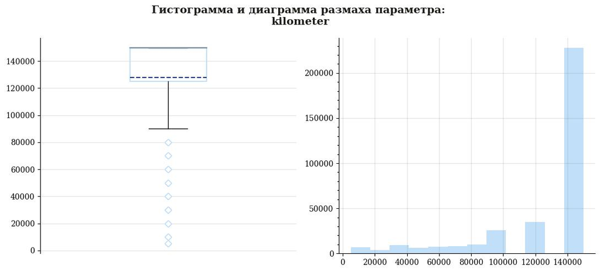

```
ShapiroResult(statistic=0.6382415294647217, pvalue=0.0)

AndersonResult(statistic=53889.44105241046, critical_values=array([0.576, 0.656, 0.787, 0.918, 1.092]), significance_level=array([15. , 10. ,  5. ,  2.5,  1. ]), fit_result=  params: FitParams(loc=128111.35907952033, scale=37857.903938963536)
 success: True
 message: '`anderson` successfully fit the distribution to the data.')
```

```
mean    128111.36
std      37857.90
max     150000.00
min       5000.00
50%     150000.00
Name: kilometer, dtype: float64
```

```
Коэффициент асимметрии: -1.71

Коэффициент эксцесса: 1.86
```

```python
print('Датафрейм autos_df:')
for column in num_columns:
    try:
        show_distribution_graphs(autos_df, column)
        print('')
    except:
        print(f'Нет столбца {column} в датафрейме.')
# вывод графиков распределения числовых параметров для датафрейма autos_df и результатов статистических тестов
```

На диаграмме размаха `price` есть большая группа **выбросов**, которые лежат выше третьего квартиля и смещают среднее значение вверх. Похожая картина наблюдается на диаграмме переменной `power`. Рассмотрим такие выбросы подробнее.

```python
autos_df[autos_df['price'] < 50]
# срез данных
```

|  | price | vehicle_type | registration_year | gearbox | power | model | kilometer | registration_month | fuel_type | brand | repaired |
| --- | --- | --- | --- | --- | --- | --- | --- | --- | --- | --- | --- |
| 7 | 0 | sedan | 1980 | manual | 50 | other | 40000 | 7 | petrol | volkswagen | no |
| 40 | 0 | small | 1990 | manual | 0 | corsa | 150000 | 1 | petrol | opel | unknown |
| 59 | 1 | suv | 1994 | manual | 286 | other | 150000 | 11 | other | sonstige_autos | unknown |
| 89 | 1 | sedan | 1995 | manual | 113 | e_klasse | 150000 | 4 | petrol | mercedes_benz | no |
| 115 | 0 | small | 1999 | unknown | 0 | other | 5000 | 0 | petrol | volkswagen | unknown |
| ... | ... | ... | ... | ... | ... | ... | ... | ... | ... | ... | ... |
| 354205 | 0 | small | 2000 | manual | 65 | corsa | 150000 | 0 | petrol | opel | yes |
| 354238 | 0 | small | 2002 | manual | 60 | fiesta | 150000 | 3 | petrol | ford | unknown |
| 354248 | 0 | small | 1999 | manual | 53 | swift | 150000 | 3 | petrol | suzuki | unknown |
| 354277 | 0 | small | 1999 | manual | 37 | arosa | 150000 | 7 | petrol | seat | yes |
| 354364 | 0 | sedan | 2005 | manual | 0 | colt | 150000 | 7 | petrol | mitsubishi | yes |

11511 rows × 11 columns

Автомобили с ценой **менее 50 евро** - это скорее всего *аномалии*. Существуют бюджетные автомобили на вторичном рынке, которые стоят от 50 до 500 евро. Чаще всего такие машины имеют маленький кузов и объём двигателя (1-2 л.), а также большой пробег. Год выпуска приходится на период с 1960 по 1995 гг.

```python
autos_df[autos_df['price'] > 15000].head()
# срез данных
```

|  | price | vehicle_type | registration_year | gearbox | power | model | kilometer | registration_month | fuel_type | brand | repaired |
| --- | --- | --- | --- | --- | --- | --- | --- | --- | --- | --- | --- |
| 1 | 18300 | coupe | 2011 | manual | 190 | other | 125000 | 5 | petrol | audi | yes |
| 14 | 17999 | suv | 2011 | manual | 190 | navara | 70000 | 3 | petrol | nissan | no |
| 33 | 18000 | sedan | 2007 | auto | 218 | 3er | 20000 | 5 | petrol | bmw | no |
| 172 | 19750 | convertible | 2006 | manual | 305 | mustang | 50000 | 7 | petrol | ford | no |
| 179 | 16449 | wagon | 2015 | auto | 110 | fabia | 10000 | 8 | petrol | skoda | no |

Максимальная цена автомобиля составляет 20000 евро, что соответствует примерно 1856000 руб. Такая цена не является аномальным значением, оставим такие машины в датафрейме.

```python
autos_df = autos_df[(autos_df['price'] >= 50)]
# срез данных
```

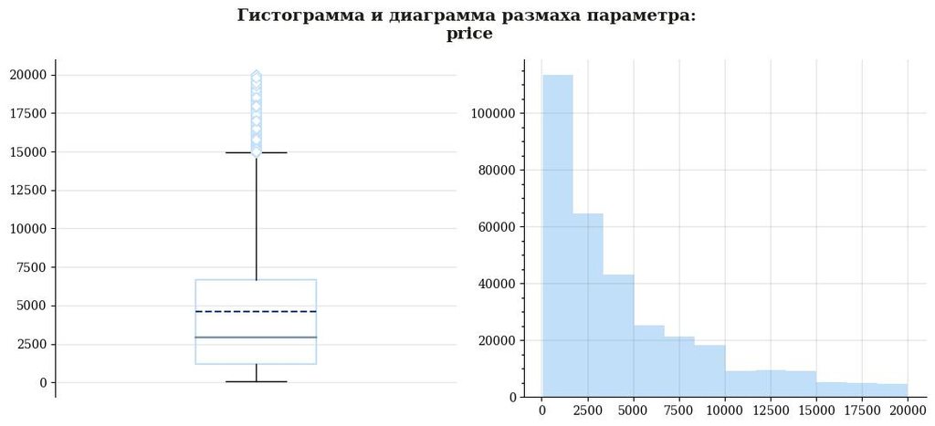

```
ShapiroResult(statistic=0.832763671875, pvalue=0.0)

AndersonResult(statistic=18039.57263878791, critical_values=array([0.576, 0.656, 0.787, 0.918, 1.092]), significance_level=array([15. , 10. ,  5. ,  2.5,  1. ]), fit_result=  params: FitParams(loc=4629.202771394962, scale=4545.787810600543)
 success: True
 message: '`anderson` successfully fit the distribution to the data.')
```

```
mean     4629.20
std      4545.79
max     20000.00
min        50.00
50%      2950.00
Name: price, dtype: float64
```

```
Коэффициент асимметрии: 1.39

Коэффициент эксцесса: 1.24
```

```python
show_distribution_graphs(autos_df, 'price')
# использование функции show_distribution_graphs для столбца price
```

```python
print(f'Процент удалённых строк: {round((1 - (autos_df.shape[0] / autos_df_copy.shape[0])) * 100, 2)}%')
```

```
Процент удалённых строк: 7.4%
```

Аномалии мы удалили.

Медианное значение цены составляет **2950** евро, а стандартное отклонение - 4546.

Распределение цены скошено вправо, коэффициент асимметрии составляет 1.39. На основании результатов статистических тестов и визуального анализа можно сделать вывод, что данные выборки *не следуют нормальному распределению*.

```python
autos_df[autos_df['power'] < 15].head()
# срез данных
```

|  | price | vehicle_type | registration_year | gearbox | power | model | kilometer | registration_month | fuel_type | brand | repaired |
| --- | --- | --- | --- | --- | --- | --- | --- | --- | --- | --- | --- |
| 0 | 480 | sedan | 1993 | manual | 0 | golf | 150000 | 0 | petrol | volkswagen | unknown |
| 32 | 245 | sedan | 1994 | manual | 0 | golf | 150000 | 2 | petrol | volkswagen | no |
| 37 | 1500 | bus | 2016 | manual | 0 | kangoo | 150000 | 1 | petrol | renault | no |
| 54 | 4700 | wagon | 2005 | manual | 0 | signum | 150000 | 0 | petrol | opel | no |
| 55 | 550 | wagon | 1999 | manual | 0 | astra | 150000 | 8 | petrol | opel | yes |

Самый маломощный малолитражный автомобиль на вторичном рынке на данный момент - это авто с двухтактным двухцилиндровым двигателем объемом 356 куб.см. или мощностью 15 л.с. Другие транспортные средства с мощностью **менее 15 л.с.** относятся к *аномальным значениям* или не являются автомобилями.

```python
autos_df[autos_df['power'] == 0].head()
# срез данных
```

|  | price | vehicle_type | registration_year | gearbox | power | model | kilometer | registration_month | fuel_type | brand | repaired |
| --- | --- | --- | --- | --- | --- | --- | --- | --- | --- | --- | --- |
| 0 | 480 | sedan | 1993 | manual | 0 | golf | 150000 | 0 | petrol | volkswagen | unknown |
| 32 | 245 | sedan | 1994 | manual | 0 | golf | 150000 | 2 | petrol | volkswagen | no |
| 37 | 1500 | bus | 2016 | manual | 0 | kangoo | 150000 | 1 | petrol | renault | no |
| 54 | 4700 | wagon | 2005 | manual | 0 | signum | 150000 | 0 | petrol | opel | no |
| 55 | 550 | wagon | 1999 | manual | 0 | astra | 150000 | 8 | petrol | opel | yes |

Нулевая мощность может указывать на то, что автомобиль не оборудован бензиновым двигателем либо это электрический автомобиль без двигателя внутреннего сгорания. В нашем случае это скорее аномалии.

```python
autos_df = autos_df[(autos_df['power'] >= 15)]
# срез данных
```

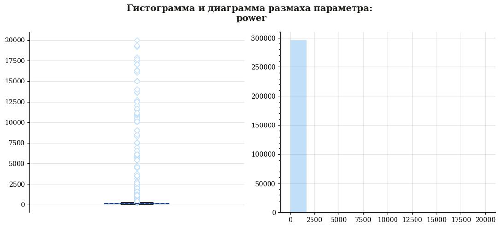

```
ShapiroResult(statistic=0.11423498392105103, pvalue=0.0)

AndersonResult(statistic=56945.42424935993, critical_values=array([0.576, 0.656, 0.787, 0.918, 1.092]), significance_level=array([15. , 10. ,  5. ,  2.5,  1. ]), fit_result=  params: FitParams(loc=124.39002467633438, scale=191.01020866871355)
 success: True
 message: '`anderson` successfully fit the distribution to the data.')
```

```
mean      124.39
std       191.01
max     20000.00
min        15.00
50%       111.00
Name: power, dtype: float64
```

```
Коэффициент асимметрии: 63.23

Коэффициент эксцесса: 4910.15
```

```python
show_distribution_graphs(autos_df, 'power')
# использование функции show_distribution_graphs для столбца power
```

```python
print(f'Процент удалённых строк: {round((1 - (autos_df.shape[0] / autos_df_copy.shape[0])) * 100, 2)}%')
```

```
Процент удалённых строк: 16.52%
```

У гистограммы видна правосторонняя асимметрия. Коэффициент асимметрии равен 63, а стандартное отклонение - 191 л.с., поэтому *нет оснований полагать, что величина распределена нормально*. Данное предположение подтверждается статистическими тестами.

Теперь посмотрим на распределение категориальных признаков.

```python
def show_bar_graphs(df, df_name):

    print('')
    print(f'Датафрейм {df_name}: \n')

    cols = ['#7990A3', '#C1DFF9', '#748CDB', '#163B88', '#192D45']
    # настройка цветовой палитры

    for column in cat_columns:

        if df[column].nunique() < 4:
            fig = plt.figure(figsize=(5, 5))
        else:
            fig = plt.figure(figsize=(7, 6))

        ax1 = fig.add_subplot(1, 1, 1)
        # создание сетки из подграфика
        ax1.spines['top'].set_visible(False)
        ax1.spines['right'].set_visible(False)
        # удаление линий осей
        sns.barplot(data=df[column].value_counts().reset_index().head(),
                    x='index',
                    y=column,
                    ax=ax1,
                    palette=cols
                   )
        # построение столбчатой диаграммы
        plt.ylabel('число машин', fontsize=12)
        plt.xlabel(column, fontsize=12)
        plt.xticks(rotation=50)
        # подпись осей

        ax1.set_title(f'''Распределение машин по признаку: \n{column}''',
                      fontsize=14,
                      fontweight='demi',
                      color='#1B1B17',
                      loc='left')
        # добавление заголовка

        fig.tight_layout()
        plt.show()
# создание функции для построения столбчатых графиков по категориальным переменным
```

```
Датафрейм autos_df:
```

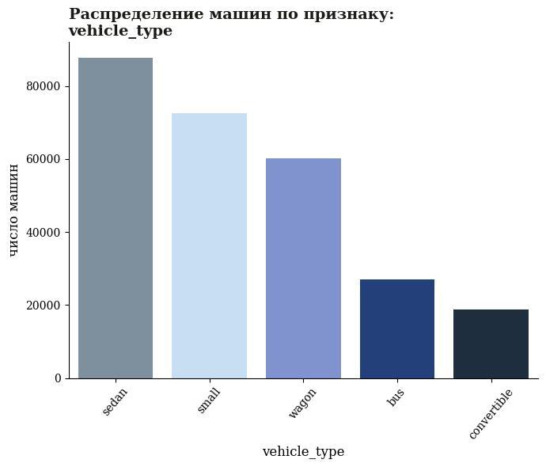

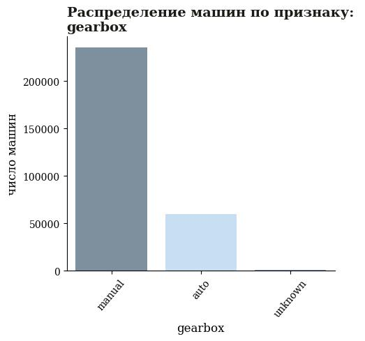

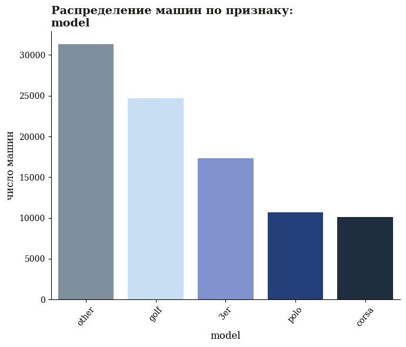

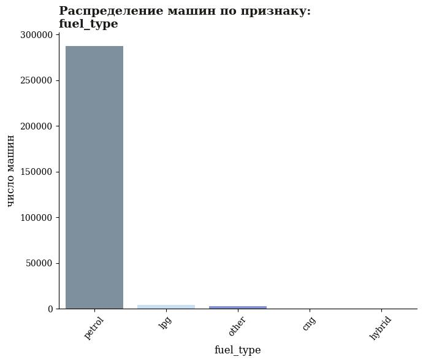

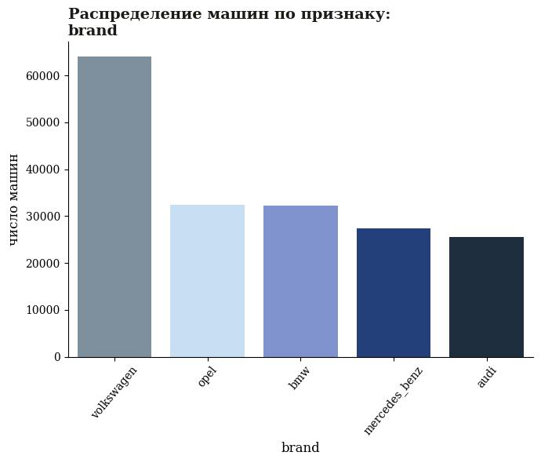

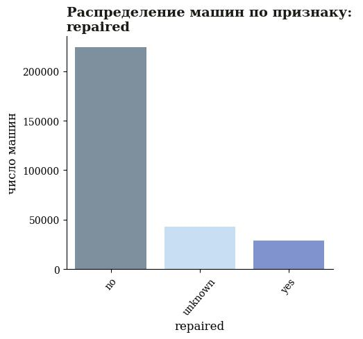

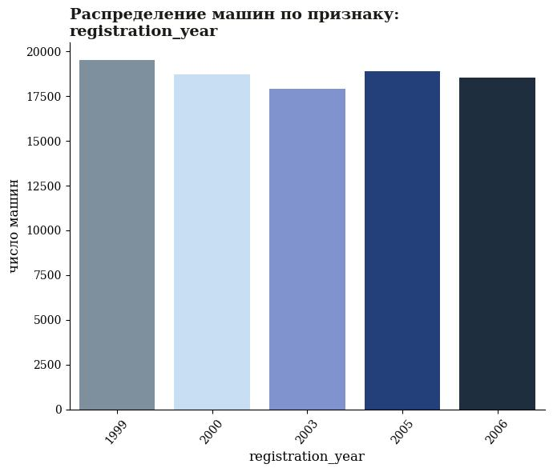

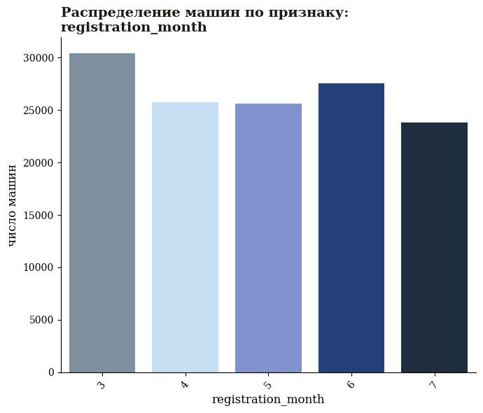

```python
show_bar_graphs(autos_df, 'autos_df')
# применение функции show_bar_graphs к датафрейму autos_df
```

В выборке преобладают автомобили с кузовом sedan, на втором месте по распространённости авто с маленьким кузовом. Большинство с механической коробкой передач и бензиновым двигателем. Чаще всего встречаются владельцы машин Volkswagen Golf. Больше 200 тыс. авто не были пока в ремонте.

### Корреляционный анализ

На данном этапе исследования наша задача - оценить направление и силу взаимосвязи между переменными с помощью корреляционного анализа, а также выявить возможную мультиколлинеарность между числовыми входными признаками.

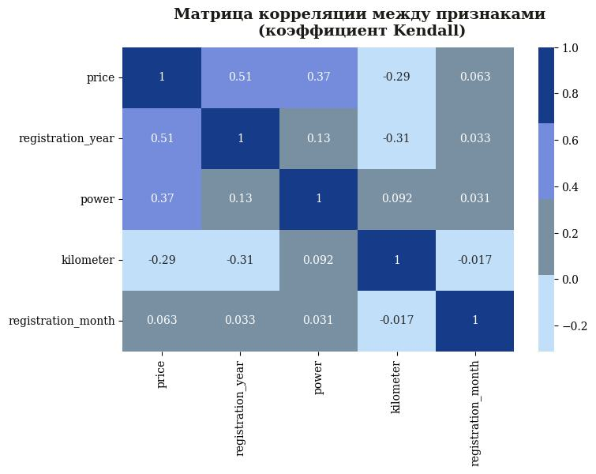

```python
fig = plt.figure(figsize=(8, 5))
fig.suptitle(f'Матрица корреляции между признаками\n (коэффициент Kendall)', fontsize=14, fontweight='demi', color='#1B1B17')
ax1 = fig.add_subplot(1, 1, 1)
sns.heatmap(autos_df.corr(method='kendall'), ax=ax1, cmap=['#C1DFF9', '#7990A3', '#748CDB', '#163B88'], annot=True)

plt.show()
# построение тепловой карты корреляций kendall
```

Целевая переменная `price` имеет **слабую** корреляцию с числовыми признаками `registration_year` и `power`. Коэффициенты корреляции равны 0.51 и 0.37 соответственно. В данном случае мы *не можем говорить о наличии мультиколлинеарности* между входными признаками, так как все коэффициенты корреляции меньше 0.8.

```
interval columns not set, guessing: ['price', 'registration_year', 'power', 'kilometer', 'registration_month']
```

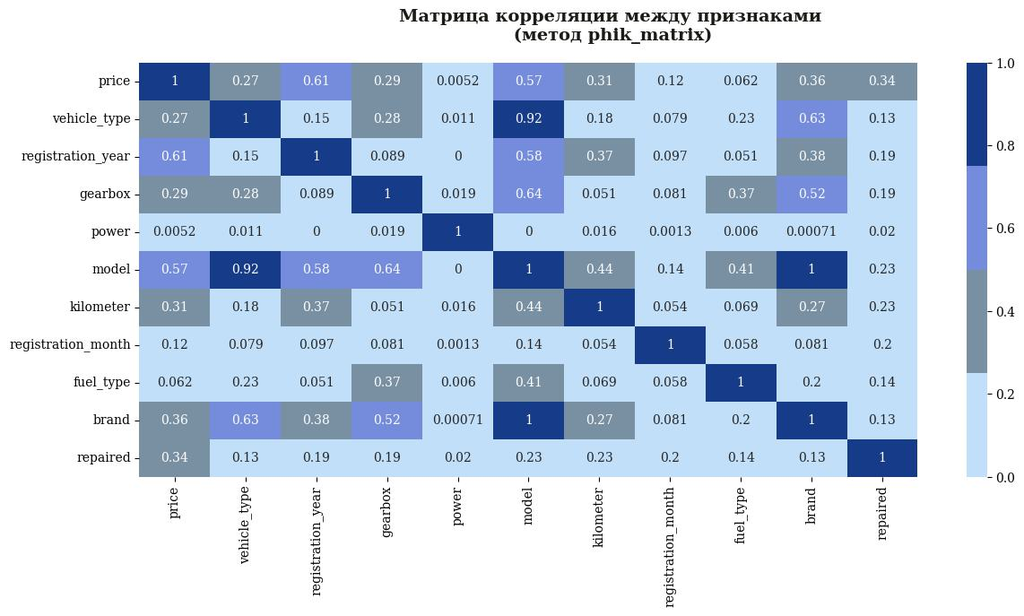

```python
fig = plt.figure(figsize=(14, 6))
fig.suptitle(f'Матрица корреляции между признаками\n (метод phik_matrix)', fontsize=14, fontweight='demi', color='#1B1B17')
ax1 = fig.add_subplot(1, 1, 1)
sns.heatmap(autos_df.phik_matrix(), ax=ax1, cmap=['#C1DFF9', '#7990A3', '#748CDB', '#163B88'], annot=True)

plt.show()
# построение тепловой карты корреляций с помощью метода phik_matrix()
```

Среди категориальных переменных сильно коррелируют между собой признак `model` и `vehicle_type`, а также `model` и `brand`, что предсказуемо.

## Подготовка данных

```python
autos_df = autos_df.reset_index(drop=True)
# обновление индексов
```

Сначала переведём категориальные значения столбцов в количественные для линейной регресии **LinearRegression** c помощью *OHE кодирования*.

```python
autos_df_ohe = pd.get_dummies(autos_df, drop_first=True)
autos_df_ohe.head()
# переводим категориальные переменные в индикаторные (dummy)
```

|  | price | registration_year | power | kilometer | registration_month | vehicle_type_convertible | vehicle_type_coupe | vehicle_type_other | vehicle_type_sedan | vehicle_type_small | ... | brand_smart | brand_sonstige_autos | brand_subaru | brand_suzuki | brand_toyota | brand_trabant | brand_volkswagen | brand_volvo | repaired_unknown | repaired_yes |
| --- | --- | --- | --- | --- | --- | --- | --- | --- | --- | --- | --- | --- | --- | --- | --- | --- | --- | --- | --- | --- | --- |
| 0 | 18300 | 2011 | 190 | 125000 | 5 | 0 | 1 | 0 | 0 | 0 | ... | 0 | 0 | 0 | 0 | 0 | 0 | 0 | 0 | 0 | 1 |
| 1 | 9800 | 2004 | 163 | 125000 | 8 | 0 | 0 | 0 | 0 | 0 | ... | 0 | 0 | 0 | 0 | 0 | 0 | 0 | 0 | 1 | 0 |
| 2 | 1500 | 2001 | 75 | 150000 | 6 | 0 | 0 | 0 | 0 | 1 | ... | 0 | 0 | 0 | 0 | 0 | 0 | 1 | 0 | 0 | 0 |
| 3 | 3600 | 2008 | 69 | 90000 | 7 | 0 | 0 | 0 | 0 | 1 | ... | 0 | 0 | 0 | 0 | 0 | 0 | 0 | 0 | 0 | 0 |
| 4 | 650 | 1995 | 102 | 150000 | 10 | 0 | 0 | 0 | 1 | 0 | ... | 0 | 0 | 0 | 0 | 0 | 0 | 0 | 0 | 0 | 1 |

5 rows × 308 columns

```python
X_ohe = autos_df_ohe.drop(['price'], axis=1)
y_ohe = autos_df_ohe['price']

X_train_ohe, X_valid_ohe, y_train_ohe, y_valid_ohe = train_test_split(
    X_ohe,
    y_ohe,
    test_size = VALID_SIZE,
    random_state = RANDOM_STATE)

X_test_ohe, X_valid_ohe, y_test_ohe, y_valid_ohe = train_test_split(
    X_valid_ohe,
    y_valid_ohe,
    test_size = TEST_SIZE,
    random_state = RANDOM_STATE)
# разделение выборки на тренировочную, валидационную и тестовую для LinearRegression
```

```python
columns_scale = ['registration_year', 'power', 'kilometer', 'registration_month']
# список признаков для масштабирования
```

```python
scaler = StandardScaler()
scaler.fit(X_train_ohe[columns_scale])
X_train_ohe[columns_scale] = scaler.transform(X_train_ohe[columns_scale])
X_valid_ohe[columns_scale] = scaler.transform(X_valid_ohe[columns_scale])
X_test_ohe[columns_scale] = scaler.transform(X_test_ohe[columns_scale])
# масштабирование количественных признаков
```

```python
X_train_ohe.head()
# вывод первых 5 строк
```

|  | registration_year | power | kilometer | registration_month | vehicle_type_convertible | vehicle_type_coupe | vehicle_type_other | vehicle_type_sedan | vehicle_type_small | vehicle_type_suv | ... | brand_smart | brand_sonstige_autos | brand_subaru | brand_suzuki | brand_toyota | brand_trabant | brand_volkswagen | brand_volvo | repaired_unknown | repaired_yes |
| --- | --- | --- | --- | --- | --- | --- | --- | --- | --- | --- | --- | --- | --- | --- | --- | --- | --- | --- | --- | --- | --- |
| 247219 | 0.948103 | 0.584010 | 0.588711 | -1.116953 | 0 | 1 | 0 | 0 | 0 | 0 | ... | 0 | 0 | 0 | 0 | 0 | 0 | 0 | 0 | 0 | 0 |
| 64760 | 0.181511 | 0.079460 | 0.588711 | -0.000502 | 0 | 0 | 0 | 0 | 0 | 0 | ... | 0 | 0 | 0 | 0 | 0 | 0 | 1 | 0 | 0 | 0 |
| 211232 | -0.585082 | -0.251810 | 0.588711 | -1.116953 | 0 | 0 | 0 | 1 | 0 | 0 | ... | 0 | 0 | 0 | 0 | 0 | 0 | 0 | 0 | 1 | 0 |
| 49124 | -0.125127 | 0.115135 | 0.588711 | -1.396066 | 0 | 0 | 0 | 1 | 0 | 0 | ... | 0 | 0 | 0 | 0 | 0 | 0 | 0 | 0 | 0 | 1 |
| 173720 | 0.488148 | 0.130424 | 0.588711 | 0.278611 | 0 | 0 | 0 | 0 | 0 | 0 | ... | 0 | 0 | 0 | 0 | 0 | 0 | 0 | 0 | 0 | 0 |

5 rows × 307 columns

```python
print(f'''Количество строк в тренировочной выборке: {X_train_ohe.shape[0]}
Количество признаков в тренировочной выборке: {X_train_ohe.shape[1]}''')
```

```
Количество строк в тренировочной выборке: 177498
Количество признаков в тренировочной выборке: 307
```

```python
print(f'''Количество строк в валидационной выборке: {X_valid_ohe.shape[0]}
Количество признаков в валидационной выборке: {X_valid_ohe.shape[1]}''')
```

```
Количество строк в валидационной выборке: 59166
Количество признаков в валидационной выборке: 307
```

```python
print(f'''Количество строк в тестовой выборке: {X_test_ohe.shape[0]}
Количество признаков в тестовой выборке: {X_test_ohe.shape[1]}''')
```

```
Количество строк в тестовой выборке: 59166
Количество признаков в тестовой выборке: 307
```

Теперь подготовим данные для моделей, которые мы будем обучать с перебором параметров в pipeline - **DecisionTreeRegressor и KNeighborsRegressor**. В данном случае используем порядковое кодирование для категориальных переменных *OrdinalEncoder*.

```python
X = autos_df.drop(['price'], axis=1)
y = autos_df['price']

X_train, X_test, y_train, y_test = train_test_split(
    X,
    y,
    test_size = TEST_SIZE_PIPE,
    random_state = RANDOM_STATE)
# разделение выборки на тренировочную и тестовую для моделей DecisionTreeRegressor и KNeighborsRegressor
```

```python
print(f'''Количество строк в тренировочной выборке: {X_train.shape[0]}
Количество признаков в тренировочной выборке: {X_train.shape[1]}''')
```

```
Количество строк в тренировочной выборке: 221872
Количество признаков в тренировочной выборке: 10
```

```python
print(f'''Количество строк в тестовой выборке: {X_test.shape[0]}
Количество признаков в тестовой выборке: {X_test.shape[1]}''')
```

```
Количество строк в тестовой выборке: 73958
Количество признаков в тестовой выборке: 10
```

```python
columns_scale = ['power', 'kilometer']
# список признаков для масштабирования
```

```python
X_ord = autos_df.drop(['price'], axis=1)
y_ord = autos_df['price']

encoder = OrdinalEncoder(handle_unknown='use_encoded_value', unknown_value=np.nan)
encoder.fit(X_ord[cat_columns])
X_ord[cat_columns] = encoder.transform(X_ord[cat_columns])

scaler.fit(X_ord[columns_scale])
X_ord[columns_scale] = scaler.transform(X_ord[columns_scale])
# порядковое кодирование категориальных признаков
```

```python
X_ord.head()
# вывод первых 5 строк
```

|  | vehicle_type | registration_year | gearbox | power | model | kilometer | registration_month | fuel_type | brand | repaired |
| --- | --- | --- | --- | --- | --- | --- | --- | --- | --- | --- |
| 0 | 2.0 | 77.0 | 1.0 | 0.343490 | 166.0 | -0.090641 | 5.0 | 5.0 | 1.0 | 2.0 |
| 1 | 6.0 | 70.0 | 0.0 | 0.202136 | 117.0 | -0.090641 | 8.0 | 5.0 | 14.0 | 1.0 |
| 2 | 5.0 | 67.0 | 1.0 | -0.258573 | 116.0 | 0.590515 | 6.0 | 5.0 | 38.0 | 0.0 |
| 3 | 5.0 | 74.0 | 1.0 | -0.289985 | 101.0 | -1.044260 | 7.0 | 5.0 | 31.0 | 0.0 |
| 4 | 4.0 | 61.0 | 1.0 | -0.117219 | 11.0 | 0.590515 | 10.0 | 5.0 | 2.0 | 2.0 |

```python
X_train_ord, X_valid_ord, y_train_ord, y_valid_ord = train_test_split(
    X_ord,
    y_ord,
    test_size = VALID_SIZE,
    random_state = RANDOM_STATE)

X_test_ord, X_valid_ord, y_test_ord, y_valid_ord = train_test_split(
    X_valid_ord,
    y_valid_ord,
    test_size = TEST_SIZE,
    random_state = RANDOM_STATE)
# разделение выборки на тренировочную, валидационную и тестовую для моделей DecisionTreeRegressor и KNeighborsRegressor
```

```python
print(f'''Количество строк в тренировочной выборке: {X_train_ord.shape[0]}
Количество признаков в тренировочной выборке: {X_train_ord.shape[1]}''')
```

```
Количество строк в тренировочной выборке: 177498
Количество признаков в тренировочной выборке: 10
```

```python
print(f'''Количество строк в валидационной выборке: {X_valid_ord.shape[0]}
Количество признаков в валидационной выборке: {X_valid_ord.shape[1]}''')
```

```
Количество строк в валидационной выборке: 59166
Количество признаков в валидационной выборке: 10
```

```python
print(f'''Количество строк в тестовой выборке: {X_test_ord.shape[0]}
Количество признаков в тестовой выборке: {X_test_ord.shape[1]}''')
```

```
Количество строк в тестовой выборке: 59166
Количество признаков в тестовой выборке: 10
```

## Обучение моделей

### Линейная модель

```python
model_lin = LinearRegression()
# инициализируем модель линейной регрессии
model_lin.fit(X_train_ohe, y_train_ohe)
# обучение модели на тренировочных данных
predictions_ohe = model_lin.predict(X_valid_ohe)
# получаем предсказания модели на валидационных данных
rmse = mean_squared_error(y_valid_ohe, predictions_ohe)**0.5
# подсчёт метрики rmse - среднеквадратичной ошибки
print(f'Метрика RMSE по тренировочной выборке: {round(rmse, 3)}')
```

```
Метрика RMSE по тренировочной выборке: 2835.953
```

### Модель DecisionTreeRegressor и KNeighborsRegressor

```python
ord_pipe = Pipeline(
    [('simpleImputer_before_ord', SimpleImputer(missing_values=np.nan, strategy='most_frequent')),
     ('ord',  OrdinalEncoder(handle_unknown='use_encoded_value',
                             unknown_value=np.nan)
        ),
     ('simpleImputer_after_ord', SimpleImputer(missing_values=np.nan, strategy='most_frequent'))
    ]
)
# создаём пайплайн для подготовки признаков из списка cat_columns

data_preprocessor = ColumnTransformer(
    [('ord', ord_pipe, cat_columns),
     ('num', MinMaxScaler(), num_columns[1:])
    ],
    remainder='passthrough'
)
# создаём общий пайплайн для подготовки данных - кодирования и масштабирования

pipe_final = Pipeline([
    ('preprocessor', data_preprocessor),
    ('models', DecisionTreeRegressor(random_state=RANDOM_STATE))
])
# создаём итоговый пайплайн: подготовка данных и модель
```

```python
param_grid = [
    {
        'models': [DecisionTreeRegressor(random_state=RANDOM_STATE)],
        'models__max_depth': range(2, 20),
        'models__max_features': range(2, 6),
        'preprocessor__num': [StandardScaler(), MinMaxScaler(), 'passthrough']
    },
    # словарь для модели DecisionTreeRegressor()

    {
        'models': [KNeighborsRegressor()],
        'models__n_neighbors': range(2, 20),
        'preprocessor__num': [StandardScaler(), MinMaxScaler(), 'passthrough']
    }
    # словарь для модели KNeighborsRegressor()
]
```

```python
randomized_search = RandomizedSearchCV(
    pipe_final,
    param_grid,
    cv=3,
    scoring='neg_root_mean_squared_error',
    random_state=RANDOM_STATE,
    n_jobs=-1
)
# запуск поиска гиперпараметров с помощью RandomizedSearchCV

randomized_search.fit(X_train, y_train)
# обучение модели

print('Лучшая модель и её параметры:\n\n', randomized_search.best_estimator_)
```

```
Лучшая модель и её параметры:

 Pipeline(steps=[('preprocessor',
                 ColumnTransformer(remainder='passthrough',
                                   transformers=[('ord',
                                                  Pipeline(steps=[('simpleImputer_before_ord',
                                                                   SimpleImputer(strategy='most_frequent')),
                                                                  ('ord',
                                                                   OrdinalEncoder(handle_unknown='use_encoded_value',
                                                                                  unknown_value=nan)),
                                                                  ('simpleImputer_after_ord',
                                                                   SimpleImputer(strategy='most_frequent'))]),
                                                  ['vehicle_type', 'gearbox',
                                                   'model', 'fuel_type',
                                                   'brand', 'repaired',
                                                   'registration_year',
                                                   'registration_month']),
                                                 ('num', MinMaxScaler(),
                                                  ['power', 'kilometer'])])),
                ('models', KNeighborsRegressor(n_neighbors=12))])
```

```python
print('Метрика RMSE лучшей модели по валидационной выборке:', round(randomized_search.best_score_ * (-1), 3))
```

```
Метрика RMSE лучшей модели по валидационной выборке: 2038.662
```

### LightGBM

```python
X_gbm = autos_df.drop(['price'], axis=1)
y_gbm = autos_df['price']

for column in cat_columns:
    if X_gbm.dtypes[column] == "object":
        X_gbm[column] = X_gbm[column].astype('category')
# перевод категориальных признаков в тип category
X_gbm.dtypes
```

```
vehicle_type          category
registration_year        int64
gearbox               category
power                    int64
model                 category
kilometer                int64
registration_month       int64
fuel_type             category
brand                 category
repaired              category
dtype: object
```

```python
X_train_gbm, X_valid_gbm, y_train_gbm, y_valid_gbm = train_test_split(
    X_gbm,
    y_gbm,
    test_size = VALID_SIZE,
    random_state = RANDOM_STATE)

X_test_gbm, X_valid_gbm, y_test_gbm, y_valid_gbm = train_test_split(
    X_valid_gbm,
    y_valid_gbm,
    test_size = TEST_SIZE,
    random_state = RANDOM_STATE)
# разделение выборки на тренировочную, валидационную и тестовую для модели LGBMRegressor
```

```python
print(f'''Количество строк в тренировочной выборке: {X_train_gbm.shape[0]}
Количество признаков в тренировочной выборке: {X_train_gbm.shape[1]}''')
```

```
Количество строк в тренировочной выборке: 177498
Количество признаков в тренировочной выборке: 10
```

```python
print(f'''Количество строк в валидационной выборке: {X_valid_gbm.shape[0]}
Количество признаков в валидационой выборке: {X_valid_gbm.shape[1]}''')
```

```
Количество строк в валидационной выборке: 59166
Количество признаков в валидационой выборке: 10
```

```python
print(f'''Количество строк в тестовой выборке: {X_test_gbm.shape[0]}
Количество признаков в тестовой выборке: {X_test_gbm.shape[1]}''')
```

```
Количество строк в тестовой выборке: 59166
Количество признаков в тестовой выборке: 10
```

```python
params = {'num_leaves': [n for n in range(20, 250, 60)],
          'learning_rate': [0.01, 0.1],
          'n_estimators': [500, 1000],
          'max_depth': [n for n in range(5, 30, 2)],
          'verbose': [-1]
         }
# объявление словаря с значениями параметров для модели
```

```python
model_lgb = lgb.LGBMRegressor(random_state=RANDOM_STATE)
# инициализируем модель
cv_lgb = RandomizedSearchCV(estimator=model_lgb,
                            param_distributions=params,
                            scoring='neg_root_mean_squared_error',
                            cv=3,
                            verbose=-1)
# запуск поиска гиперпараметров с помощью RandomizedSearchCV
cv_lgb.fit(X_train_gbm, y_train_gbm)
# обучение модели
```

```
RandomizedSearchCV(cv=3, estimator=LGBMRegressor(random_state=42),
                   param_distributions={'learning_rate': [0.01, 0.1],
                                        'max_depth': [5, 7, 9, 11, 13, 15, 17,
                                                      19, 21, 23, 25, 27, 29],
                                        'n_estimators': [500, 1000],
                                        'num_leaves': [20, 80, 140, 200],
                                        'verbose': [-1]},
                   scoring='neg_root_mean_squared_error', verbose=-1)
```

```python
print(cv_lgb.best_params_)
print('')
print(f'Метрика RMSE по валидационной выборке: {round((cv_lgb.best_score_ * (-1)), 3)}')
```

```
{'verbose': -1, 'num_leaves': 140, 'n_estimators': 500, 'max_depth': 27, 'learning_rate': 0.1}

Метрика RMSE по валидационной выборке: 1538.817
```

### Вывод:

По результатам обучения и подбора параметров для моделей самая маленькая среднеквадратичная ошибка RMSE *1538.817* у модели с градиентным бустингом **LGBMRegressor** ('num_leaves': 140, 'n_estimators': 500, 'max_depth': 27, 'learning_rate': 0.1).

## Анализ моделей

Подсчитаем время обучения модели LinearRegression на тренировочных данных.

```python
%%time
model_lin = LinearRegression()
model_lin.fit(X_train_ohe, y_train_ohe)
# обучение модели
```

```
CPU times: user 7.92 s, sys: 1.76 s, total: 9.68 s
Wall time: 10.8 s
```

```
LinearRegression()
```

Подсчитаем время предсказания значений модели LinearRegression на валидационных данных.

```python
%%time
predictions_ohe = model_lin.predict(X_valid_ohe)
# предсказание значений
```

```
CPU times: user 110 ms, sys: 106 ms, total: 217 ms
Wall time: 250 ms
```

Оценим качество модели LinearRegression.

```python
print(f'Значение метрики RMSE для валидационной выборки линейной модели: {round(mean_squared_error(y_valid_ohe, predictions_ohe)**0.5, 3)}')
```

```
Значение метрики RMSE для валидационной выборки линейной модели: 2835.953
```

Подсчитаем время обучения модели KNeighborsRegressor на тренировочных данных.

```python
%%time
model_knr = KNeighborsRegressor(n_neighbors=12)
model_knr.fit(X_train_ord, y_train_ord)
# обучение модели
```

```
CPU times: user 412 ms, sys: 41.9 ms, total: 454 ms
Wall time: 722 ms
```

```
KNeighborsRegressor(n_neighbors=12)
```

Подсчитаем время предсказания значений модели KNeighborsRegressor на валидационных данных.

```python
%%time
predictions_ord = model_knr.predict(X_valid_ord)
# предсказание значений
```

```
CPU times: user 8.96 s, sys: 149 ms, total: 9.11 s
Wall time: 11.1 s
```

Оценим качество модели KNeighborsRegressor.

```python
print(f'Значение метрики RMSE для валидационной выборки модели KNeighborsRegressor: {round(mean_squared_error(y_valid_ord, predictions_ord)**0.5, 3)}')
```

```
Значение метрики RMSE для валидационной выборки модели KNeighborsRegressor: 1964.079
```

Подсчитаем время обучения модели LGBMRegressor на тренировочных данных.

```python
%%time
model_lgb = lgb.LGBMRegressor(random_state=RANDOM_STATE,
                              n_estimators=500,
                              num_leaves=140,
                              max_depth=27,
                              learning_rate=0.1)
model_lgb.fit(X_train_gbm, y_train_gbm)
# обучение модели
```

```
CPU times: user 9.28 s, sys: 249 ms, total: 9.53 s
Wall time: 5.37 s
```

```
LGBMRegressor(max_depth=27, n_estimators=500, num_leaves=140, random_state=42)
```

Подсчитаем время предсказания значений модели LGBMRegressor на валидационных данных.

```python
%%time
predictions_gbm = model_lgb.predict(X_valid_gbm)
# предсказание значений
```

```
CPU times: user 4.7 s, sys: 59.8 ms, total: 4.76 s
Wall time: 3.09 s
```

Оценим качество модели LGBMRegressor.

```python
print(f'Значение метрики RMSE для валидационной выборки модели LGBMRegressor: {round(mean_squared_error(y_valid_gbm, predictions_gbm)**0.5, 3)}')
```

```
Значение метрики RMSE для валидационной выборки модели LGBMRegressor: 1510.661
```

### Вывод:

Быстрее всего *обучается* модель **KNeighborsRegressor 722 ms**, на втором месте - LGBMRegressor 5.37 s, на последнем - LinearRegression 10.8 s. По времени *предсказания* значений лидер **LinearRegression 250 ms**, далее следуют LGBMRegressor 3.09 s и KNeighborsRegressor 11.1 s. Модель с самой маленькой среднеквадратичной ошибкой *RMSE* - **LGBMRegressor 1510.661**, на втором месте KNeighborsRegressor 1964.079 и на последнем LinearRegression 2835.953.

Модель LinearRegression не соответствует критерию RMSE < 2500. Остаётся выбор между двумя моделями LGBMRegressor и KNeighborsRegressor. Модель KNeighborsRegressor обучается гораздо быстрее, а её RMSE не намного больше метрики модели LGBMRegressor. Наш выбор - модель **KNeighborsRegressor**. Проведём подсчёт RMSE на тестовых данных для лучшей модели.

```python
print(f'Значение метрики RMSE для тестовой выборки модели KNeighborsRegressor: {round(mean_squared_error(y_test_ord, (model_knr.predict(X_test_ord)))**0.5, 3)}')
```

```
Значение метрики RMSE для тестовой выборки модели KNeighborsRegressor: 1949.056
```

## Итоговый вывод

На начальном этапе была проведена предобработка данных. Названия столбцов мы перевели в нижний 'змеиный' регистр и удалили 4 явных дубликатов в датафрейме autos_df. В столбце `fuel_type` переименовали неявный дубликат gasoline в petrol. Пропуски были заполнены, а некорректные типы данных не были найдены.

В ходе исследовательского анализа данных были рассмотрены все числовые и категориальные признаки. С помощью гистограмм и статистических тестов мы оценили характер распределенний, а по диаграммам размаха определили медианные значения параметров и проверили наличие выбросов. Из столбцов `price` и `power` удалили часть выбросов и аномальные значения. Анализ категориальных переменных показал, что в выборке преобладают автомобили с кузовом sedan, механической коробкой передач и бензиновым двигателем, которые пока не были в ремонте.

На этапе корреляционного анализа мы построили матрицу корреляций. У целевой переменной `price` слабая корреляция была выявлена с признаками `registration_year` и `power`. Мультиколлинеарность между числовыми входными признаками не была обнаружена.

После обучения моделей и подбора гиперпараметров с помощью RandomizedSearchCV мы оценили качество моделей метрикой RMSE, подсчитали время обучения и предсказания значений на валидационной выборке. Самая низкая среднеквадратичная ошибка 1510.661 оказалась у LGBMRegressor, время обучения - 5.37 s. Наиболее выигрышной по сравнению остальными моделями является модель KNeighborsRegressor с параметром n_neighbors=12. Её метрика RMSE 1964.079 не намного выше значения среднеквадратичной ошибки 1510.661, но при этом время её обучения всего 722 ms. Нашей рекомендацией будет использование модели KNeighborsRegressor (n_neighbors=12). На тестовой выборке её метрика качества RMSE составила 1949.056.